# Data Exploration

Zicheng (Stone) Shi  
2/29/2020

# Pre-processing

## Read data and load packages

```r
## read in data and load library
library(tidyverse)

raw <- read.csv("/Volumes/GoogleDrive/My Drive/University of Notre Dame/MSBA Spring Semester/career/interview/CreditNinja/OA/raw_data.csv")
glimpse(raw)
```

```
Observations: 32,561
Variables: 15
$ age            <int> 39, 50, 38, 53, 28, 37, 49, 52, 31, 42, 37, …
$ workclass      <fct>  State-gov,  Self-emp-not-inc,  Private,  Pr…
$ fnlwgt         <int> 77516, 83311, 215646, 234721, 338409, 284582…
$ education      <fct>  Bachelors,  Bachelors,  HS-grad,  11th,  Ba…
$ education_num  <int> 13, 13, 9, 7, 13, 14, 5, 9, 14, 13, 10, 13, …
$ marital_status <fct>  Never-married,  Married-civ-spouse,  Divorc…
$ occupation     <fct>  Adm-clerical,  Exec-managerial,  Handlers-c…
$ relationship   <fct>  Not-in-family,  Husband,  Not-in-family,  H…
$ race           <fct>  White,  White,  White,  Black,  Black,  Whi…
$ sex            <fct>  Male,  Male,  Male,  Male,  Female,  Female…
$ capital_gain   <int> 2174, 0, 0, 0, 0, 0, 0, 0, 14084, 5178, 0, 0…
$ capital_loss   <int> 0, 0, 0, 0, 0, 0, 0, 0, 0, 0, 0, 0, 0, 0, 0,…
$ hours_per_week <int> 40, 13, 40, 40, 40, 40, 16, 45, 50, 40, 80, …
$ native_country <fct>  United-States,  United-States,  United-Stat…
$ income         <fct>  <=50K,  <=50K,  <=50K,  <=50K,  <=50K,  <=5…
```

## Data cleansing

First, I will do a quick summary of the data set to check outliers and NAs.

```r
summary(raw)
```

```
      age                    workclass         fnlwgt
 Min.   :17.00    Private         :22696   Min.   :  12285
 1st Qu.:28.00    Self-emp-not-inc: 2541   1st Qu.: 117827
 Median :37.00    Local-gov       : 2093   Median : 178356
 Mean   :38.58    ?               : 1836   Mean   : 189778
 3rd Qu.:48.00    State-gov       : 1298   3rd Qu.: 237051
 Max.   :90.00    Self-emp-inc    : 1116   Max.   :1484705
                 (Other)          :  981
         education     education_num                  marital_status
  HS-grad     :10501   Min.   : 1.00    Divorced             : 4443
  Some-college: 7291   1st Qu.: 9.00    Married-AF-spouse    :   23
  Bachelors   : 5355   Median :10.00    Married-civ-spouse   :14976
  Masters     : 1723   Mean   :10.08    Married-spouse-absent:  418
  Assoc-voc   : 1382   3rd Qu.:12.00    Never-married        :10683
  11th        : 1175   Max.   :16.00    Separated            : 1025
 (Other)      : 5134                    Widowed              :  993
            occupation            relationship
  Prof-specialty :4140    Husband       :13193
  Craft-repair   :4099    Not-in-family : 8305
  Exec-managerial:4066    Other-relative:  981
  Adm-clerical   :3770    Own-child     : 5068
  Sales          :3650    Unmarried     : 3446
  Other-service  :3295    Wife          : 1568
 (Other)         :9541
                  race            sex         capital_gain
  Amer-Indian-Eskimo:  311    Female:10771   Min.   :    0
  Asian-Pac-Islander: 1039    Male  :21790   1st Qu.:    0
  Black             : 3124                   Median :    0
  Other             :  271                   Mean   : 1078
  White             :27816                   3rd Qu.:    0
                                             Max.   :99999

  capital_loss    hours_per_week         native_country
 Min.   :   0.0   Min.   : 1.00    United-States:29170
 1st Qu.:   0.0   1st Qu.:40.00    Mexico       :  643
 Median :   0.0   Median :40.00    ?            :  583
 Mean   :  87.3   Mean   :40.44    Philippines  :  198
 3rd Qu.:   0.0   3rd Qu.:45.00    Germany      :  137
 Max.   :4356.0   Max.   :99.00    Canada       :  121
                                  (Other)       : 1709
    income
  <=50K:24720
  >50K : 7841
```

```r
## replace the question marks with NA
raw$workclass <- gsub("?", NA, raw$workclass, fixed = TRUE)
raw$native_country <- gsub("?", NA, raw$native_country, fixed = TRUE)
```

I’ll remove those NAs because they only account for 7% of our data. It is safe to drop them.

```r
raw_2 <- raw %>%
  filter(!is.na(workclass)) %>%
  filter(!is.na(native_country)) %>%
  mutate_at(c("workclass", "native_country"), as.factor)

summary(raw_2)
```

```
      age                    workclass         fnlwgt
 Min.   :17.00    Private         :22286   Min.   :  13769
 1st Qu.:28.00    Self-emp-not-inc: 2499   1st Qu.: 117634
 Median :37.00    Local-gov       : 2067   Median : 178429
 Mean   :38.43    State-gov       : 1279   Mean   : 189802
 3rd Qu.:47.00    Self-emp-inc    : 1074   3rd Qu.: 237624
 Max.   :90.00    Federal-gov     :  943   Max.   :1484705
                 (Other)          :   21
         education    education_num                  marital_status
  HS-grad     :9841   Min.   : 1.00    Divorced             : 4215
  Some-college:6680   1st Qu.: 9.00    Married-AF-spouse    :   21
  Bachelors   :5044   Median :10.00    Married-civ-spouse   :14066
  Masters     :1627   Mean   :10.12    Married-spouse-absent:  370
  Assoc-voc   :1307   3rd Qu.:13.00    Never-married        : 9731
  11th        :1049   Max.   :16.00    Separated            :  939
 (Other)      :4621                    Widowed              :  827
            occupation            relationship
  Prof-specialty :4038    Husband       :12463
  Craft-repair   :4030    Not-in-family : 7727
  Exec-managerial:3992    Other-relative:  889
  Adm-clerical   :3721    Own-child     : 4471
  Sales          :3584    Unmarried     : 3212
  Other-service  :3212    Wife          : 1407
 (Other)         :7592
                  race            sex         capital_gain
  Amer-Indian-Eskimo:  286    Female: 9784   Min.   :    0
  Asian-Pac-Islander:  895    Male  :20385   1st Qu.:    0
  Black             : 2819                   Median :    0
  Other             :  231                   Mean   : 1092
  White             :25938                   3rd Qu.:    0
                                             Max.   :99999

  capital_loss     hours_per_week         native_country
 Min.   :   0.00   Min.   : 1.00    United-States:27511
 1st Qu.:   0.00   1st Qu.:40.00    Mexico       :  610
 Median :   0.00   Median :40.00    Philippines  :  188
 Mean   :  88.35   Mean   :40.93    Germany      :  128
 3rd Qu.:   0.00   3rd Qu.:45.00    Puerto-Rico  :  109
 Max.   :4356.00   Max.   :99.00    Canada       :  107
                                   (Other)       : 1516
    income
  <=50K:22661
  >50K : 7508
```

## Class Variable Distribution

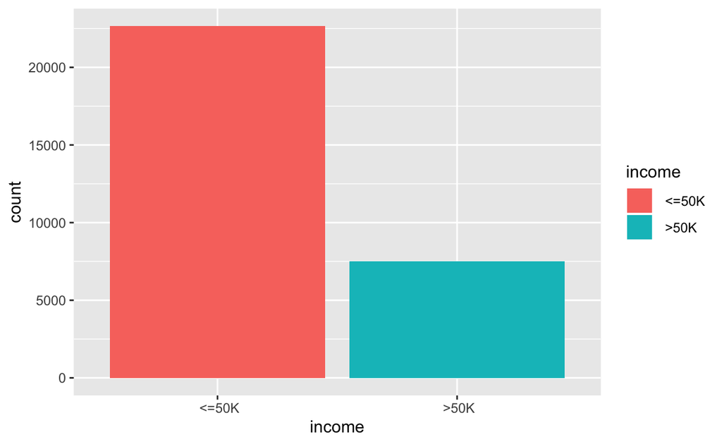

```r
raw_2 %>%
  ggplot(aes(x = income, fill = income)) +
  geom_bar()
```

The class distribution is quite imbalanced, I’ll handle this in the later part of analysis.

# Questions 1

**Which race, sex combination is most represented in this data set? Which race, sex combination is least likely to make more than $50K?**

```r
## combine the race and sex columns
raw_2$Race_Sex <- as.factor(paste(raw_2$race, raw_2$sex, sep = ""))
table(raw_2$Race_Sex)
```

```
 Amer-Indian-Eskimo Female    Amer-Indian-Eskimo Male
                       107                        179
 Asian-Pac-Islander Female    Asian-Pac-Islander Male
                       294                        601
              Black Female                 Black Male
                      1400                       1419
              Other Female                 Other Male
                        87                        144
              White Female                 White Male
                      7896                      18042
```

Based on the table above, I can see the **White Male** combination is most represented in the data set.

```r
table(raw_2$income)
```

```
 <=50K   >50K
 22661   7508
```

```r
table(raw_2$education)
```

```
         10th          11th          12th       1st-4th       5th-6th
          822          1049           377           151           288
      7th-8th           9th    Assoc-acdm     Assoc-voc     Bachelors
          558           455          1008          1307          5044
    Doctorate       HS-grad       Masters     Preschool   Prof-school
          375          9841          1627            45           542
 Some-college
         6680
```

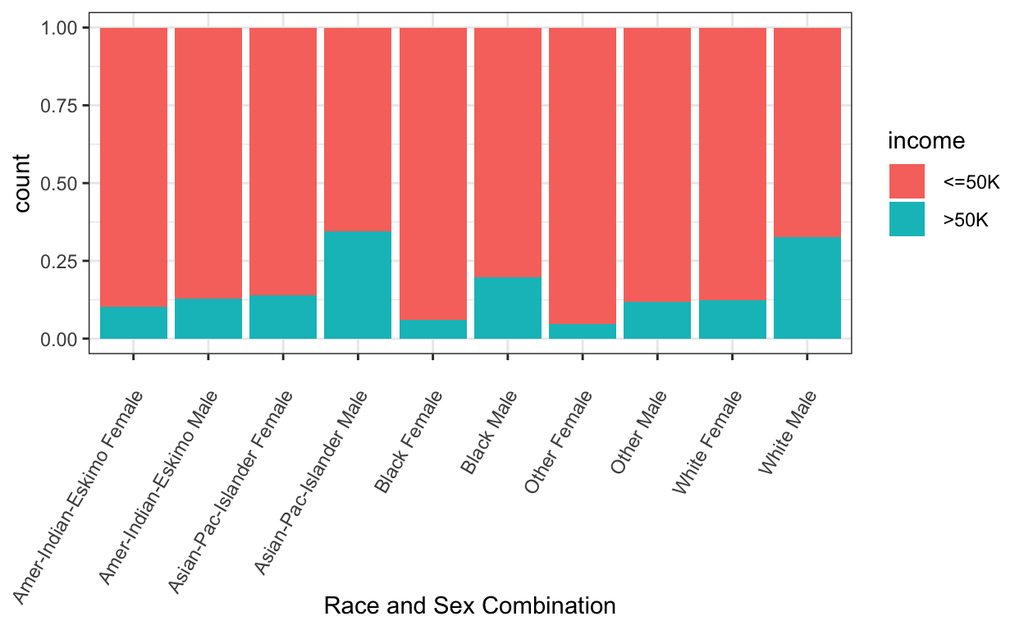

```r
ggplot(raw_2, aes(x = Race_Sex, fill = income)) +
  geom_bar(position = 'fill') +
  theme_bw() +
  theme(axis.text.x  = element_text(angle=60, hjust=1, vjust=0.9)) +
  labs(x = "Race and Sex Combination")
```

# Question 2

**Are there any columns that can be dropped from this data set without damaging the information contained within the data?**

I’ll remove the **education_num** column. The reason is that **education_num** contains the same information as **education**, we can see the more advanced the degree is, the larger the number of education years will be.

So it is safe for me to drop `education_num` column without damaging the information.

```r
raw_2 <- raw_2 %>%
  dplyr::select(-education_num)
```

# Question 3

**What steps did you take to prepare the data for your analysis and why did you need to do those steps? What tools did you use to do this data preparation and the associated analyses?**

As I’ve done in my previous steps, before doing data analysis, we need to:

- Convert data to the proper types (e.g. from character to factor)
- Use various imputation techniques to handle missing data, such as mean imputation, predictive imputation, etc. In my previous preprocessing, I simply dropped these missing values because it only accounts for 7% of the entire data set
- Remove outliers. Outliers will have high leverage and might move the analysis towards another direction

Also, I can check the correlation between continuous variables to see if there is any high correlation.

```r
library(ggcorrplot)

#index vector numeric variables
numericVars <- which(sapply(raw_2, FUN = is.numeric))

#saving names for use later on
numericVarNames <- names(numericVars)

cat("There are", length(numericVarNames), "numeric variables")
```

```
There are 5 numeric variables
```

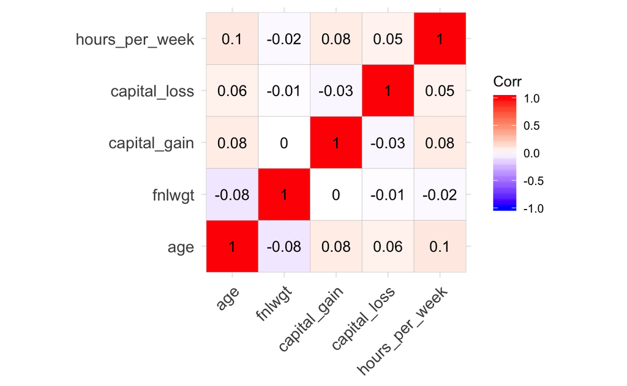

```r
raw_numVar <- raw_2[, numericVars]
corr <- cor(raw_numVar, use = 'pairwise.complete.obs')

ggcorrplot(corr, lab = TRUE)
```

I don’t see any high correlation here, so we are good to include them for future analysis.

Another thing I can do with categorical variables is to check their relationship with the class variable. If I see any variable that has low chi-square value and high p-value, I will know the categorical variable is independent on the class variable, so it is useless to include them in the model training stage.

```r
chi.square <- vector()
p.value <- vector()
cateVar <- raw_2 %>%
  dplyr::select(-income) %>%
  purrr::keep(is.factor)

for (i in 1:length(cateVar)) {
 p.value[i] <- chisq.test(raw_2$income, unname(unlist(cateVar[i])), correct = FALSE)[3]$p.value
 chi.square[i] <- unname(chisq.test(raw_2$income, unname(unlist(cateVar[i])), correct = FALSE)[1]$statistic)
}

chi_sqaure_test <- tibble(variable = names(cateVar)) %>%
  add_column(chi.square = chi.square) %>%
  add_column(p.value = p.value)
knitr::kable(chi_sqaure_test)
```

| variable | chi.square | p.value |
| --- | --- | --- |
| workclass | 806.6021 | 0 |
| education | 4072.6672 | 0 |
| marital_status | 6063.7772 | 0 |
| occupation | 3690.5126 | 0 |
| relationship | 6235.7589 | 0 |
| race | 304.5680 | 0 |
| sex | 1416.1243 | 0 |
| native_country | 317.6842 | 0 |
| Race_Sex | 1623.8228 | 0 |

I’ll keep all of the categorical variables because they are all dependent on the class variable based on the chi-square test.

# Question 4

**The column “fnlwgt” is a continuous variable that has a complicated, interconnected definition. For this column is a higher value or a lower value more likely to predict high income?**

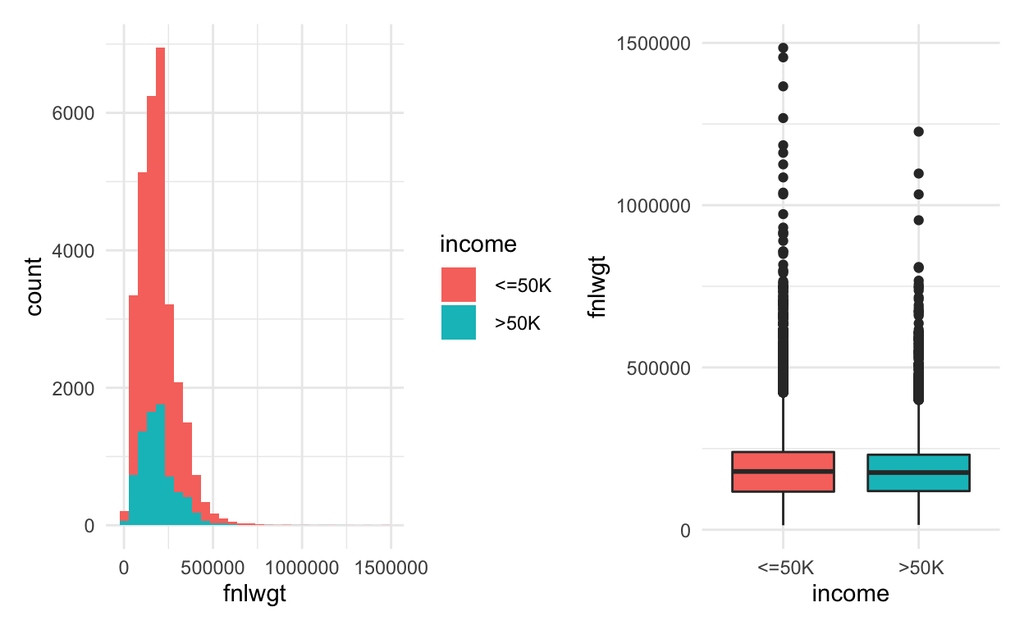

```r
library(patchwork) # for displaying the plots

fnlwgt_histogram <- ggplot(raw_2, aes(x = fnlwgt, fill = income)) +
  geom_histogram() +
  theme_minimal()

fnlwgt_boxplot <- ggplot(raw_2, aes(x = income, y = fnlwgt, fill = income)) +
  geom_boxplot() +
  theme_minimal() +
  theme(legend.position = 'none')

fnlwgt_histogram | fnlwgt_boxplot
```

The distribution of these two groups are quite similar. There is no big difference between the mean of two groups.

I’ll do a t-test to check if the difference between two groups is significant.

- *Null hypothesis*: the difference between two groups is not significant
- *Alternative hypothesis*: the difference between the two groups is significant

```r
t.test(raw_2$fnlwgt ~ raw_2$income, alternative = "two.sided")
```

```
    Welch Two Sample t-test

data:  raw_2$fnlwgt by raw_2$income
t = 1.5919, df = 13246, p-value = 0.1114
alternative hypothesis: true difference in means is not equal to 0
95 percent confidence interval:
 -508.7977 4908.1920
sample estimates:
mean in group  <=50K  mean in group  >50K
            190349.7             188150.0
```

The mean `fnlwgt` of higher income group is lower than the other group, so it is possible that lower fnlwgt value will lead to higher income, but the p-value is 0.11, which is greater than our pre-determined threshold 0.05, so we failed to reject the null hypothesis. We know the mean difference between two groups isn’t significant. We won’t be able to tell if lower fnlwgt value or higher fnlwgt value will lead to higher income.

# Question 5

**If we could only have access to one of the columns (not the target column) and still needed to make an income prediction, which column would you choose and why? What if you could have access to 3 columns?**

There are a lot of feature selection techniques in the wild, such as Lasso, random forest, and xgboost. Here I’ll use decision tree to select the best predictor(s) becuase it is simple and fast.

The decision tree algorithm that I’m going to implement uses *Gini impurity* measure to determine the optimal feature to split upon.

Even though we’re not going to do the predictions here, but it is still a good idea to split the data and handle the class imbalanced problem before building the model.

```r
## split the data using a stratified sampling approach.
library(caTools)
set.seed(888)
sample_set <- raw_2 %>%
  pull(.) %>%
  sample.split(SplitRatio = .7)

raw_train <- subset(raw_2, sample_set == TRUE)
raw_test <- subset(raw_2, sample_set == FALSE)
```

```r
## use SMOTE to handle class imbalance
library(DMwR)
set.seed(888)
raw_train <- SMOTE(income ~ ., data.frame(raw_train), perc.over = 100, perc.under = 200)
```

Then we can put the data into the decision tree model.

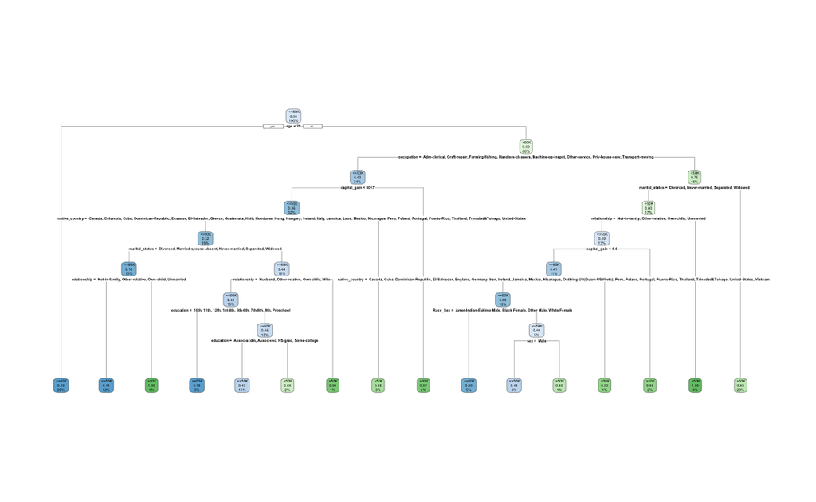

```r
library(rpart)
library(rpart.plot)
tree.mod <-
  rpart(
    income ~.,
    method = "class",
    data = raw_train,
    control = rpart.control(cp = 0.004)
  )

rpart.plot(tree.mod)
```

The root node is `age`. So if I can only get access to one column, I will use `age` to try to make the best predictions because it will lead to a best quality of a split.

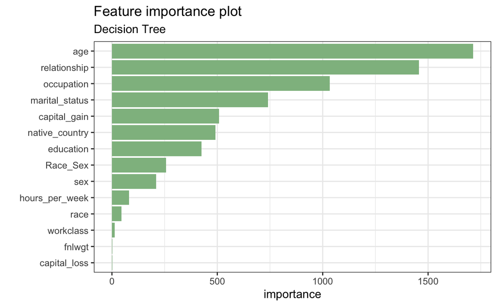

```r
tree.importance <- tree.mod$variable.importance

#barplot(t(tree.mod$variable.importance),horiz=TRUE)

importance <- as.data.frame(tree.mod$variable.importance)

names(importance) <- c("importance")

importance <- cbind(feature = rownames(importance), importance)

rownames(importance) <- 1:nrow(importance)

importance %>%
  arrange(desc(importance)) %>%
  top_n(20) %>%
  ggplot(aes(x = reorder(feature, importance), y = importance)) +
  geom_col(fill = "darkseagreen") +
  coord_flip() +
  theme_bw() +
  labs(title = "Feature importance plot", subtitle = "Decision Tree", x= "")
```

If I can use three columns, I will use: `age`, `occupation` and `relationship` based on the feature importance (gini impurity measure).

# Question 6

**What level of education should you achieve if you want to have a better than 50% chance of making more than $50K (per this data set)?**

I’ll run `education` on `income` with logistic regression because the coefficent outputs can be converted to probabilities.

```r
logit_mod <- glm(income ~ education, family = binomial(link = "logit"), data = raw_2)
summary(logit_mod)
```

```
Call:
glm(formula = income ~ education, family = binomial(link = "logit"),
    data = raw_2)

Deviance Residuals:
    Min       1Q   Median       3Q      Max
-1.6629  -0.6681  -0.5992  -0.0016   2.5399

Coefficients:
                        Estimate Std. Error z value Pr(>|z|)
(Intercept)             -2.55972    0.13513 -18.943  < 2e-16 ***
education 11th          -0.26045    0.19031  -1.369   0.1711
education 12th           0.07481    0.23583   0.317   0.7511
education 1st-4th       -0.62525    0.43798  -1.428   0.1534
education 5th-6th       -0.57577    0.32437  -1.775   0.0759 .
education 7th-8th       -0.14451    0.22078  -0.655   0.5128
education 9th           -0.28519    0.24614  -1.159   0.2466
education Assoc-acdm     1.48216    0.15328   9.669  < 2e-16 ***
education Assoc-voc      1.53031    0.14901  10.270  < 2e-16 ***
education Bachelors      2.24306    0.13810  16.242  < 2e-16 ***
education Doctorate      3.64063    0.17988  20.239  < 2e-16 ***
education HS-grad        0.93324    0.13784   6.770 1.28e-11 ***
education Masters        2.81806    0.14408  19.559  < 2e-16 ***
education Preschool    -11.00635   79.81450  -0.138   0.8903
education Prof-school    3.65342    0.16756  21.804  < 2e-16 ***
education Some-college   1.17343    0.13855   8.469  < 2e-16 ***
---
Signif. codes:  0 '***' 0.001 '**' 0.01 '*' 0.05 '.' 0.1 ' ' 1

(Dispersion parameter for binomial family taken to be 1)

    Null deviance: 33855  on 30168  degrees of freedom
Residual deviance: 29947  on 30153  degrees of freedom
AIC: 29979

Number of Fisher Scoring iterations: 12
```

I’ll convert the log odds to probabilities.

```r
library(gdata) #for trim
odds_value <- vector() #store odds
prob_value <- vector() #store probs

#remove extra space
education_levels <- trim(levels(raw_2$education)[-1])

#add eduction before corresponding grade name
education_levels <- paste("education", education_levels)


for (i in 1:length(education_levels)) {
  #calculate odds
  odds_value[i] <- exp(coef(logit_mod)["(Intercept)"] + coef(logit_mod)[education_levels[i]])
  #prob = odds / (1+odds)
  prob_value[i] <- odds_value[i] / (odds_value[i] + 1)
}

#make it as a data frame
result <- tibble(variable = trim(levels(raw_2$education)[-1])) %>%
  add_column(odds_value = odds_value) %>%
  add_column(prob_value = prob_value) %>%
  arrange(desc(prob_value))

knitr::kable(result)
```

| variable | odds_value | prob_value |
| --- | --- | --- |
| Prof-school | 2.9852941 | 0.7490775 |
| Doctorate | 2.9473684 | 0.7466667 |
| Masters | 1.2947814 | 0.5642286 |
| Bachelors | 0.7285812 | 0.4214909 |
| Assoc-voc | 0.3572170 | 0.2631982 |
| Assoc-acdm | 0.3404255 | 0.2539683 |
| Some-college | 0.2500000 | 0.2000000 |
| HS-grad | 0.1966196 | 0.1643126 |
| 12th | 0.0833333 | 0.0769231 |
| 7th-8th | 0.0669216 | 0.0627240 |
| 11th | 0.0595960 | 0.0562440 |
| 9th | 0.0581395 | 0.0549451 |
| 5th-6th | 0.0434783 | 0.0416667 |
| 1st-4th | 0.0413793 | 0.0397351 |
| Preschool | 0.0000013 | 0.0000013 |

Based on the result table, we can see if you want to have a better than 50% chance of making more than $50k, you should achieve at least a master degree.